# Practical Example: Working with Raster Data using `rasterio` and `geopandas`

## Setup

First, let's install the necessary libraries.

```python
%pip install rasterio geopandas matplotlib
```

## Download the Data

In this step, we'll download sample GeoTIFF files from the OSGeo repository. These files will be used to demonstrate raster operations in our Colab notebook. We'll use `wget` to download these files directly into our Colab environment.

```python
# Create a directory to store data
!mkdir -p data

# Download available raster files (GeoTIFF files from OSGeo)
!wget -O data/o41078a1.tif "https://download.osgeo.org/geotiff/samples/usgs/o41078a1.tif"
!wget -O data/o41078a3.tif "https://download.osgeo.org/geotiff/samples/usgs/o41078a3.tif"
```

```
--2026-08-24 21:41:42--  https://download.osgeo.org/geotiff/samples/usgs/o41078a1.tif
Resolving download.osgeo.org (download.osgeo.org)... 140.211.15.30
Connecting to download.osgeo.org (download.osgeo.org)|140.211.15.30|:443...
```

```
connected.
```

```
HTTP request sent, awaiting response...
```

```
200 OK
Length: 6238706 (5.9M) [image/tiff]
Saving to: ‘data/o41078a1.tif’

data/o41078a1.tif     0%[                    ]       0  --.-KB/s
```

[output not shown]

[output not shown]

```
data/o41078a1.tif   100%[===================>]   5.95M  8.13MB/s    in 0.7s

2026-08-24 21:41:44 (8.13 MB/s) - ‘data/o41078a1.tif’ saved [6238706/6238706]
```

```
--2026-08-24 21:41:46--  https://download.osgeo.org/geotiff/samples/usgs/o41078a3.tif
```

```
Resolving download.osgeo.org (download.osgeo.org)... 140.211.15.30
Connecting to download.osgeo.org (download.osgeo.org)|140.211.15.30|:443...
```

```
connected.
```

```
HTTP request sent, awaiting response...
```

```
200 OK
Length: 8167800 (7.8M) [image/tiff]
Saving to: ‘data/o41078a3.tif’

data/o41078a3.tif     0%[                    ]       0  --.-KB/s
```

[output not shown]

[output not shown]

[output not shown]

[output not shown]

```
data/o41078a3.tif   100%[===================>]   7.79M  7.04MB/s    in 1.1s

2026-08-24 21:41:48 (7.04 MB/s) - ‘data/o41078a3.tif’ saved [8167800/8167800]
```

## Inspecting Raster Metadata

Before visualizing the raster data, it's important to understand its structure and key attributes. We'll inspect the metadata of the GeoTIFF files to learn about the number of bands, dimensions (width and height), coordinate reference system (CRS), and more.

```python
import rasterio
import rasterio as rio

# Function to print raster metadata
def print_raster_metadata(filepath):
    with rasterio.open(filepath) as src:
        print(f"Metadata for {filepath}:")
        print(f"  - Number of Bands: {src.count}")
        print(f"  - Width: {src.width} pixels")
        print(f"  - Height: {src.height} pixels")
        print(f"  - CRS: {src.crs}")
        print(f"  - Bounds: {src.bounds}")
        print(f"  - Driver: {src.driver}")
        print(f"  - Data Type: {src.dtypes[0]}")
        print(f"  - Transform: \n{src.transform}")
        print()

# Inspect metadata for the two raster files
print_raster_metadata('data/o41078a1.tif')
print_raster_metadata('data/o41078a3.tif')
```

```
Metadata for data/o41078a1.tif:
  - Number of Bands: 1
  - Width: 5032 pixels
  - Height: 6793 pixels
  - CRS: PROJCS["WGS 84 / UTM zone 17N",GEOGCS["WGS 84",DATUM["World Geodetic System 1984",SPHEROID["WGS 84",6378137,298.257223563]],PRIMEM["Greenwich",0],UNIT["degree",0.0174532925199433,AUTHORITY["EPSG","9122"]]],PROJECTION["Transverse_Mercator"],PARAMETER["latitude_of_origin",0],PARAMETER["centra…
  - Bounds: BoundingBox(left=740726.437454, bottom=4540826.363544, right=752996.466254, top=4557390.414744)
  - Driver: GTiff
  - Data Type: uint8
  - Transform:
| 2.44, 0.00, 740726.44|
| 0.00,-2.44, 4557390.41|
| 0.00, 0.00, 1.00|

Metadata for data/o41078a3.tif:
  - Number of Bands: 1
  - Width: 5011 pixels
  - Height: 6776 pixels
  - CRS: PROJCS["WGS 84 / UTM zone 17N",GEOGCS["WGS 84",DATUM["World Geodetic System 1984",SPHEROID["WGS 84",6378137,298.257223563]],PRIMEM["Greenwich",0],UNIT["degree",0.0174532925199433,AUTHORITY["EPSG","9122"]]],PROJECTION["Transverse_Mercator"],PARAMETER["latitude_of_origin",0],PARAMETER["centra…
  - Bounds: BoundingBox(left=719741.284129, bottom=4540171.553142, right=731960.106529, top=4556694.151542)
  - Driver: GTiff
  - Data Type: uint8
  - Transform:
| 2.44, 0.00, 719741.28|
| 0.00,-2.44, 4556694.15|
| 0.00, 0.00, 1.00|
```

## Understanding Coordinate Reference Systems (CRS) and Transforms

### Coordinate Reference Systems (CRS)

A Coordinate Reference System (CRS) defines how the two-dimensional, projected map in your raster relates to real places on the earth. In geospatial analysis, it's crucial to know the CRS used by your raster data, as it affects how the data aligns with other datasets. The CRS is often specified using an EPSG code, a standard code that identifies different geographic and projected coordinate systems.

For example:

- **EPSG:4326**: This is the code for WGS84, a commonly used geographic coordinate system that uses latitude and longitude.
- **EPSG:32633**: This code refers to UTM zone 33N, a projected coordinate system commonly used for mapping in Europe.

### Transforms

The transform in a raster dataset maps the pixel locations in the raster grid to coordinates in the CRS. The transform is typically an affine transformation, which is a linear mapping method that preserves points, straight lines, and planes. The transform is crucial for aligning raster data with other spatial data.

These parameters help translate between pixel coordinates in the raster and real-world coordinates in the CRS.

The affine transformation can be represented mathematically as:

$$ \begin{pmatrix} X \\ Y \end{pmatrix} = \begin{pmatrix} A & B \\ D & E \end{pmatrix} \begin{pmatrix} i \\ j \end{pmatrix} + \begin{pmatrix} C \\ F \end{pmatrix} $$

Where:

- $X, Y$ are the real-world coordinates.
- $i, j$ are the pixel coordinates in the raster grid.

### Well-Known Text (WKT) for CRS

The Well-Known Text (WKT) format is a text markup language for representing coordinate reference systems. It is commonly used to define the spatial reference of datasets in a human-readable format.

For example:

- The WKT for **EPSG:4326** (WGS84) might look like this:

```
GEOGCS["WGS 84", DATUM["WGS_1984", SPHEROID["WGS 84",6378137,298.257223563, AUTHORITY["EPSG","7030"]], AUTHORITY["EPSG","6326"]], PRIMEM["Greenwich",0, AUTHORITY["EPSG","8901"]], UNIT["degree",0.0174532925199433, AUTHORITY["EPSG","9122"]], AUTHORITY["EPSG","4326"]]
```

- The WKT for **EPSG:32633** (UTM zone 33N) might look like this:

```
PROJCS["WGS 84 / UTM zone 33N", GEOGCS["WGS 84", DATUM["WGS_1984", SPHEROID["WGS 84",6378137,298.257223563, AUTHORITY["EPSG","7030"]], AUTHORITY["EPSG","6326"]], PRIMEM["Greenwich",0, AUTHORITY["EPSG","8901"]], UNIT["degree",0.0174532925199433, AUTHORITY["EPSG","9122"]], PROJECTION["Transverse_Mercator"], PARAMETER["latitude_of_origin",0], PARAMETER["central_meridian",15], PARAMETER["scale_factor",0.9996], PARAMETER["false_easting",500000], PARAMETER["false_northing",0], UNIT["metre",1, AUTHORITY["EPSG","9001"]], AUTHORITY["EPSG","32633"]]
```

Understanding WKT helps in interpreting and managing the spatial reference systems of your geospatial data, ensuring that different datasets align correctly when overlaid.

## Loading and Visualizing the Raster Data

Now that we have the GeoTIFF files, let's load them using `rasterio` and visualize the raster data. We'll start with a single-band raster and display it using `matplotlib`.

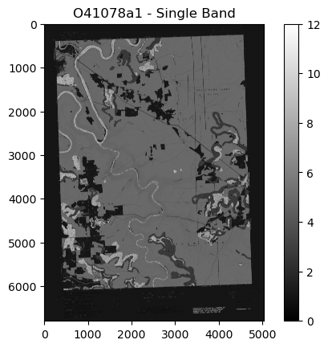

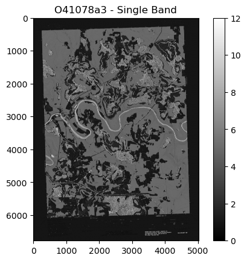

```python
import rasterio
import matplotlib.pyplot as plt

# Load the first raster file (o41078a1.tif)
with rasterio.open('data/o41078a1.tif') as src:
    o41078a1_band = src.read(1)  # Read the first band

# Display the raster data
plt.imshow(o41078a1_band, cmap='gray')
plt.title('O41078a1 - Single Band')
plt.colorbar()
plt.show()

# Load the second raster file (o41078a3.tif)
with rasterio.open('data/o41078a3.tif') as src:
    o41078a3_band = src.read(1)  # Read the first band

# Display the raster data
plt.imshow(o41078a3_band, cmap='gray')
plt.title('O41078a3 - Single Band')
plt.colorbar()
plt.show()
```

## Basic Raster Operations

Let's perform some basic operations on the raster data, such as calculating statistics (mean, max, min) and applying a simple transformation by scaling the pixel values.

```python
with rasterio.open('data/o41078a1.tif') as src:
  src.colorinterp
```

```
Statistics for Band 1:
  - Mean: 3.515009079532681
  - Min: 0
  - Max: 12
  - Std Dev: 2.211502890208182
```

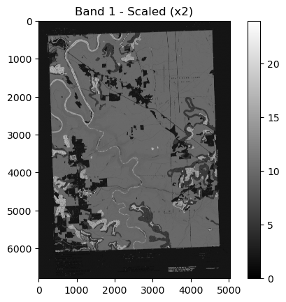

```python
import numpy as np
import rasterio
import matplotlib.pyplot as plt

# Load the raster data
with rasterio.open('data/o41078a1.tif') as src:
    band_data1 = src.read(1)  # Read the first band

# Function to calculate basic statistics of a raster band
def calculate_statistics(band_data):
    stats = {
        'mean': np.mean(band_data),
        'min': np.min(band_data),
        'max': np.max(band_data),
        'std': np.std(band_data)
    }
    return stats

# Calculate and print statistics for the first raster band
band1_stats = calculate_statistics(band_data1)
print("Statistics for Band 1:")
print(f"  - Mean: {band1_stats['mean']}")
print(f"  - Min: {band1_stats['min']}")
print(f"  - Max: {band1_stats['max']}")
print(f"  - Std Dev: {band1_stats['std']}")

# Apply a simple transformation: Scale the pixel values by a factor of 2
band1_scaled = band_data1 * 2

# Display the scaled raster data
plt.imshow(band1_scaled, cmap='gray')
plt.title('Band 1 - Scaled (x2)')
plt.colorbar()
plt.show()
```

## Best Practices When Using `rasterio`

When working with raster data in Python, `rasterio` is an essential library that provides a powerful interface for handling geospatial data. Here are some best practices to follow:

### Best Practices:

1. **Use Context Managers:**
   - Always use the `with rasterio.open(filepath) as src:` pattern when opening files. This ensures that the file is properly closed after your operations, preventing potential issues with file access.
2. **Check Metadata First:**
   - Before performing operations on raster data, inspect the metadata. This helps you understand the structure and format of the data, such as the number of bands, dimensions, and CRS.
3. **Leverage NumPy for Data Manipulation:**
   - Use NumPy to manipulate the raster data after reading it with `rasterio`. Operations like statistical analysis and transformations (e.g., scaling pixel values) are efficiently handled using NumPy arrays.
4. **Visualize Your Data:**
   - Use visualization tools like `matplotlib` to inspect your raster data visually. This step is crucial for verifying that your data looks correct after processing.

### Example in This Notebook:

In the previous cells, we followed these best practices:

- We used context managers to ensure files were opened and closed properly.
- We inspected the metadata of the raster files to understand the data we are working with.
- We performed statistical analysis and a simple transformation using NumPy.
- We visualized the raster data to confirm our operations produced the expected results.

## Saving the Modified Raster Data

After performing operations on raster data, it's often necessary to save the results. Here, we'll save the scaled raster data back to a new GeoTIFF file using `rasterio`.

```python
# Define the output file path
output_filepath = 'data/scaled_band1.tif'

# Save the scaled raster data to a new file
with rasterio.open(
    output_filepath,
    'w',
    driver='GTiff',
    height=band1_scaled.shape[0],
    width=band1_scaled.shape[1],
    count=1,  # Number of bands
    dtype=band1_scaled.dtype,
    crs=src.crs,
    transform=src.transform,
) as dst:
    dst.write(band1_scaled, 1)

print(f"Scaled raster data saved to {output_filepath}")
```

```
Scaled raster data saved to data/scaled_band1.tif
```